# Air France Search Engine Marketing (SEM) Analysis

Daniel Jeonghwan Lee

12/21/2020

## Introduction

This is an Air France SEM Analysis focusing on one main objective: Increase in Return on Advertisement or ROA. I was given a dataset containing 4510 observations and 23 variables. After doing some basic clean-ups such as deleting unnecessary or duplicate variables, I worked with 4510 observations and 14 variables.

```
## tibble [4,510 x 14] (S3: tbl_df/tbl/data.frame)
##  $ Publisher              : chr [1:4510] "Yahoo - US" "Yahoo - US" "MSN - Global" "Google - Global" ...
##  $ Keyword_Match_Type     : chr [1:4510] "Advanced" "Advanced" "Broad" "Exact" ...
##  $ Campaign               : chr [1:4510] "Western Europe Destinations" "Geo Targeted DC" "Air France Brand & French Destinations" "Air France Global Campaign" ...
##  $ Search_Engine_Bid      : num [1:4510] 6.25 6.25 0 7.5 0.25 0.125 6.25 0.325 7.5 5 ...
##  $ Clicks                 : num [1:4510] 1 1 1 59 8 42 3 47 13 19 ...
##  $ Total_Cost             : num [1:4510] 2.312 0.625 0.388 2.312 2.2 ...
##  $ Avg_Cost_per_Click     : num [1:4510] 2.3125 0.625 0.3875 0.0392 0.275 ...
##  $ Impressions            : num [1:4510] 11 6 9 401 318 722 13 547 448 129 ...
##  $ Click_Thru             : num [1:4510] 9.09 16.67 11.11 14.71 2.52 ...
##  $ Avg_Pos                : num [1:4510] 1.27 1 1.11 2 2.98 ...
##  $ Conversion             : num [1:4510] 900 100 100 3.39 12.5 ...
##  $ Total_Cost_per_Bookings: num [1:4510] 0.257 0.625 0.388 1.156 2.2 ...
##  $ Total_Revenue          : num [1:4510] 8778 1574 390 1665 935 ...
##  $ Bookings               : num [1:4510] 9 1 1 2 1 2 1 2 1 1 ...
```

### 1. Advanced Cleaning

Considering the characteristics of SEM, there are some observations that do not make sense and need to be rectified.

1. Search engine bid cannot exceed average cost per click because search engine bid is the maximum amount set for a click. Therefore, if there is any, search engine bid must be replaced with the average cost per click.
2. There cannot be any bookings without any clicks.
3. Average position, by definition, shows the place the ads get shown on a search page with 1 at the top of the page. Therefore, there cannot be any average position less than one. Any average position with 0 value and has impressions does not make sense.
4. I found a strange pattern for the ads with the average position less than 1. As the ads have the value close to 1, more impressions are generated and less impressions as it gets close to 0. This might be due to a man-made mistake and therefore I converted the position value into the right scale using the formula: (1-x) + 1
5. Click-thru and conversion rate over 50% are outliers for they are one-time occurrence that pulls up the average for the analysis.

After all the clean-ups, I reduced the observations to 4232.

```
## tibble [4,232 x 14] (S3: tbl_df/tbl/data.frame)
##  $ Publisher              : chr [1:4232] "Google - Global" "Overture - Global" "Overture - Global" "Google - US" ...
##  $ Keyword_Match_Type     : chr [1:4232] "Exact" "Standard" "Standard" "Broad" ...
##  $ Campaign               : chr [1:4232] "Air France Global Campaign" "Unassigned" "Unassigned" "Geo Targeted San Francisco" ...
##  $ Search_Engine_Bid      : num [1:4232] 7.5 0.275 0.125 6.25 0.325 ...
##  $ Clicks                 : num [1:4232] 59 8 42 3 47 13 19 29 273 231 ...
##  $ Total_Cost             : num [1:4232] 2.31 2.2 5.25 5.21 11.8 ...
##  $ Avg_Cost_per_Click     : num [1:4232] 0.0392 0.275 0.125 1.7375 0.2511 ...
##  $ Impressions            : num [1:4232] 401 318 722 13 547 ...
##  $ Click_Thru             : num [1:4232] 14.71 2.52 5.82 23.08 8.59 ...
##  $ Avg_Pos                : num [1:4232] 2 2.98 1.13 1 1.18 ...
##  $ Conversion             : num [1:4232] 3.39 12.5 4.76 33.33 4.26 ...
##  $ Total_Cost_per_Bookings: num [1:4232] 1.16 2.2 2.62 5.21 5.9 ...
##  $ Total_Revenue          : num [1:4232] 1665 935 1817 1686 3796 ...
##  $ Bookings               : num [1:4232] 2 1 2 1 2 1 1 2 10 20 ...
```

### 2. Total Revenue, Pie Chart, and Bar graphs

As per the main objective of the analysis to find a way to increase ROA, I created another variable, ROA. However, ROA is not a good metric to analyze the data because the difference between the maximum ROA, 71,906.5%, and the minimum ROA, -100%, is too large. This large ROA is due to the low cost related to SEM. To avoid any skewness in the analysis, I decided to work with total revenue instead.

```
##    Min. 1st Qu.  Median    Mean 3rd Qu.    Max.
##  -100.0  -100.0  -100.0   175.5  -100.0 71906.5
```

[figure not shown]

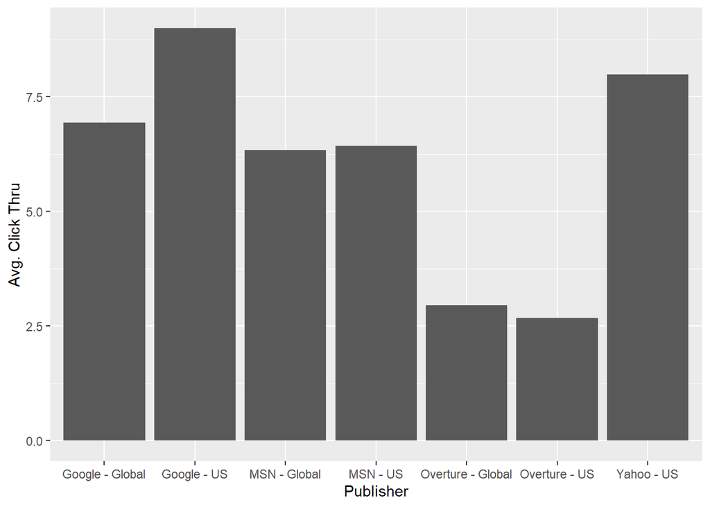

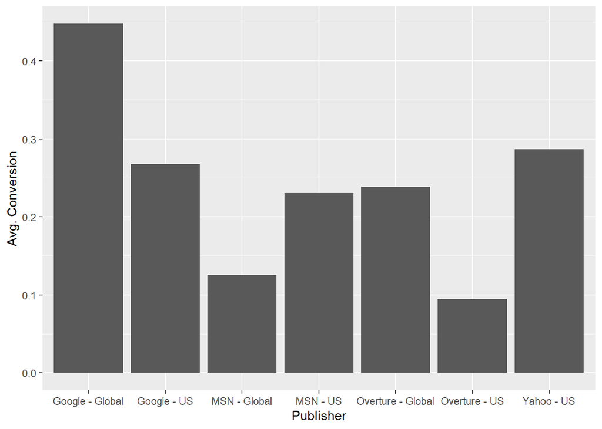

### 3. Average Position

As explained earlier, the position of the ads represents the exposure or visibility level. And as it is close to 1, it is more likely that the ads will generate more impressions, clicks, and hopefully conversions.

Then, how would publishers decide which ads get the highest position over the same keywords? They look at two elements: search engine bid and performance score. As both elements score higher, the corresponding ads will have higher chances to be displaced at a higher position.

### 3-1. Search Engine Bid and click-thru and conversion rate

I first divided the Search Engine Bid into three categories: low, medium, and high. Then, I looked at the click-thru and conversion rate per publishers to check if the ads with the higher bid strategy performs better.

Interestingly, for Google-Global, Google-US, and Yahoo-US, low or medium bid strategy ads perform better than the high bid strategy ads in both click-thru and conversion.

This suggests that Air France is paying more for the worse results and actually will be better off switching from high bid strategies to low or medium bid strategies.

*Note: MSN-US high bid strategy seems to be performing the best in the graph. But this is an outlier pulling up the average.

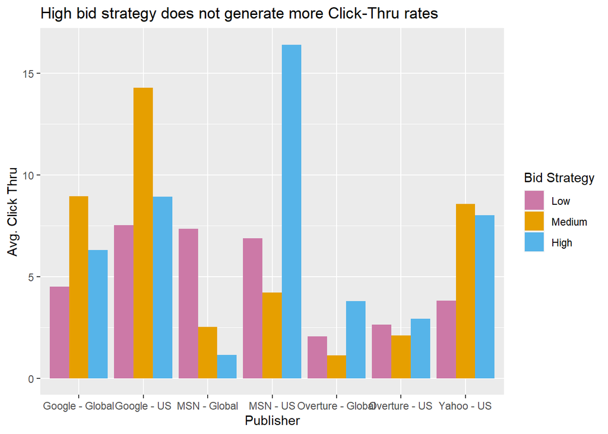

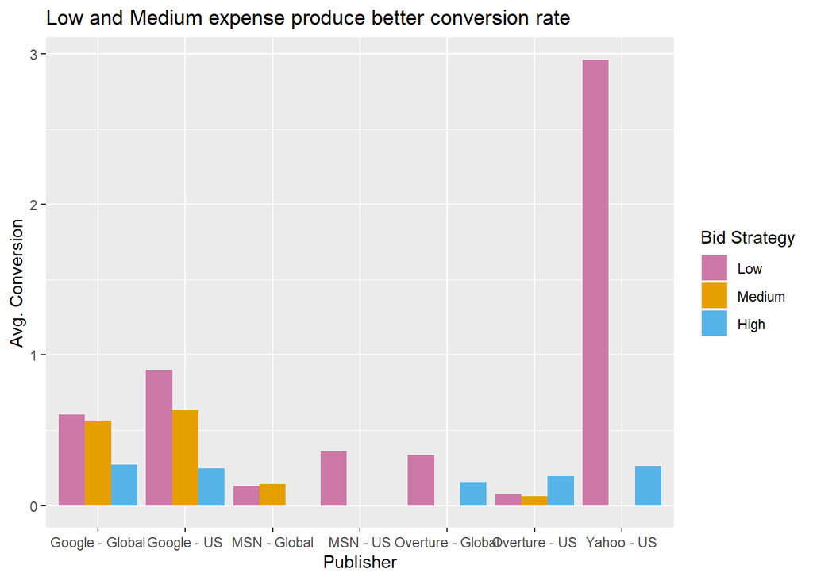

### 3-2. Performance score and click-thru and conversion rate

The other element calculated for the position, however, is not given. Therefore, I came up with a formula to estimate the performance score of the ads from the number of impressions and click-thru rate.

performance score = Impression score X click weight

*Note: Each value for the two variables is given a corresponding weight to penalize for performing less than average.

As per the bar graph, it shows that the ads with the high bid strategy has less performance score than low or medium bid strategy ads, which suggests that by paying more, Air France is ignoring the performance part, hoping that the higher bids can can boost better results.

This graph, again, suggests that switching from high bid strategy makes sense.

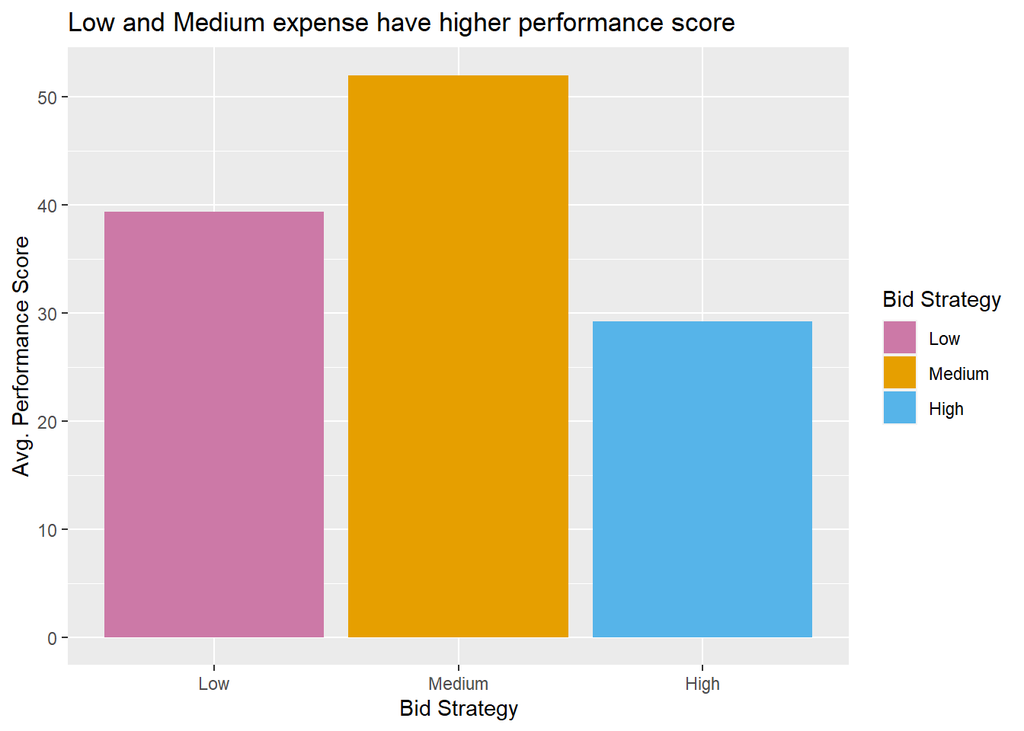

### 4. Geo-targeted Vs. Non Geo-targeted ads

With regard to the campaign types, I first divided the campaign types that utilize geo-targeted features. In theory, the campaigns that utilize the the feature would produce better results because the keyword search results will take the geographic information into account.

The data shows what I expect to see: better results for Geo-targeted campaigns. However, Yahoo - US has a mixed result with the higher click-thru and lower conversion rate for geo-targeted campaigns.

With the given dataset, I cannot identify the reason of this behavior and further anlaysis needs to be executed. But for the Google - US, changing from non geo-targeted to geo-targeted campaigns will be much more beneficial.

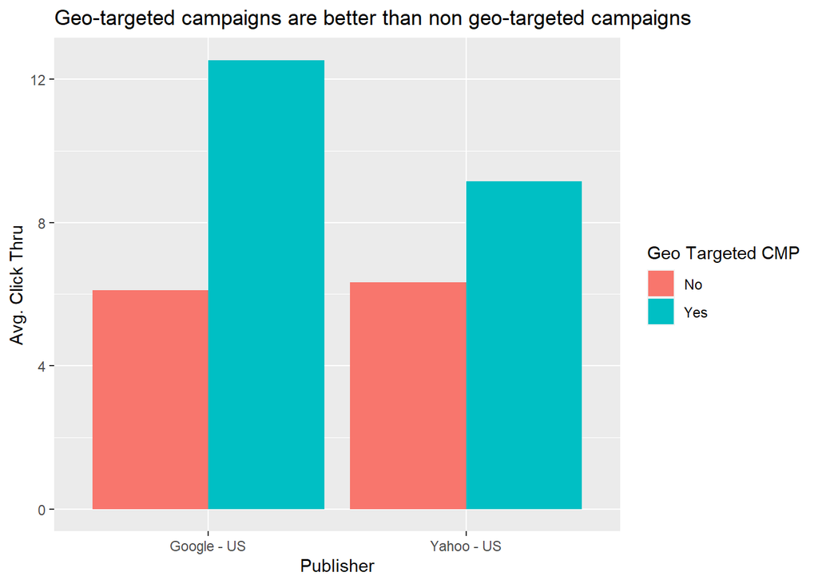

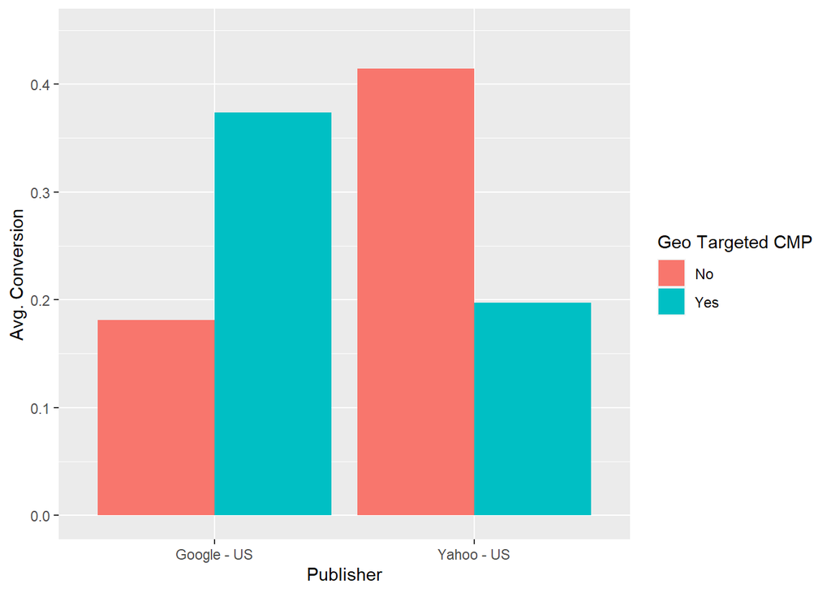

### 5. Conclusion

From the analysis, I came up with two conclusions:

1. For Google – Global, Google – US, Yahoo – US: Change high bid strategies to low or medium bid strategy Focus on optimization of the campaigns to enhance performance score
2. For Google - US: Invest more on Geo-Targeted Campaigns